# Replication of Study 3a by Craig & Richeson (2014, Psychological Science)

Author

Anmol Gupta (ganmol [at] stanford [dot] edu)

Published

July 31, 2024

## Introduction

The current report is an attempted replication of Study 3a from the Craig & Richeson (2014) paper examining the impact of racial status threat on White Americans’ political preferences.

In this project, I seek to maintain many of the same stimuli and procedures utilized in the original paper. Following a pre-test of participants’ political ideologies, participants are randomly assigned to one of two conditions – either a status-threat condition or an assuaged-threat condition. The stimuli (simulated news articles) will also remain the same across both conditions except for the key manipulation differences. After reading the new articles, participants were then asked to indicate their support for several different social policies with the prediction that White Americans would express greater endorsement of conservative policies after reading a threatening article as compared to the assuaged-threat article.

GitHub Repository: https://github.com/psych251/craig2014_rescue/tree/main

Craig & Richeson (2014) PDF: https://github.com/psych251/craig2014_rescue/blob/main/original_paper/craig-richeson-2014-on-the-precipice-of-a-majority-minority-america-perceived-status-threat-from-the-racial-demographic.pdf

Survey/Paradigm link: https://stanforduniversity.qualtrics.com/jfe/form/SV_eP73cWBRH6pANYq

Pre-registration: https://osf.io/4gtuq

## Summary of prior replication attempt

Overall, the first replication failed and did not find significant differences as a function of the article manipulation. The first replication author noted that this may have been a result of a small sample size which would not achieve 80% power. Further, the sample was not balanced in terms of baseline political ideology and was skewed liberal.

The first replication did not have any major method differences. It changed the demographic categories and removed questions not needed for the analysis.

## Methods

### Power Analysis

Using the pwr.t.test() function within the “pwr” R package, I calculated that I need 85 participants/condition to achieve 80% power. Rounding up to 90/condition, I am planning to sample 180 participants. This analysis was completed using the comparison between the status and assuaged threat conditions which was reported in the original paper.

### Materials

I will follow the materials where available for this experiment. This includes the two-item baseline ideology measure, the condition materials (i.e., the news articles, which are linked here: https://osf.io/vdg46), and the policy preferences list to assess participants’ policy preferences. The one change is the removal of a “support for same-sex marriage” policy item (legalized since the original study was run).

### Procedure

The procedure for this replication will be followed precisely. As such, participants will, upon providing informed consent, report “their demographic characteristics, including political ideology”. Participants will then be randomly assigned “an article about the projected majority-minority shift in the United States (status-threat condition) or the latter article with an extra paragraph designed to reduce status threat (assuaged-threat condition).” Finally, participants will indicate their policy preferences on an seven-item list of policies (Craig & Richeson, 2014).

### Controls

As in the original study, I will conduct an ANOVA to confirm “that participants in the status-threat condition expressed greater perceived group-status threat than did participants in the assuaged-threat condition” (Craig & Richeson, 2014).

### Analysis Plan

My key analysis of interest will be a two condition t-test. This differs from the original study and the first replication, in that both earlier iterations used ANOVAs to compare the three (assuaged threat, status threat, control) conditions, while I only have 2 conditions in my replication. More specifically, my analysis is contrasting the difference in “conservative policy score” or the standardized total score of individuals’ support of different conservative policies between the “assuaged threat” and the “status threat” conditions. In the original study (Craig & Richeson, 2014), this difference was statistically significant (F(1, 161) = 7.63, p = .006, ηp2 = .05). In the first replication, the comparison between the assuaged threat and status threat conditions was not reported, but the overall ANOVA analyzing the effect of condition on policy endorsement was not significant (F(2, 111) = 0.151, p = .86).

## Differences from Original Study and 1st replication

*Differences in sample:* The original study sampled 170 participants across three conditions, with 121 participants combined in the two conditions of interest (62 in status-threat condition; 59 in assuaged-threat condition). The first replication sampled 114 participants across all three conditions (condition breakdown was not reported). In comparison, this replication will sample 180 participants total, only across the status-threat and the assuaged-threat conditions (90 in each condition).

*Differences in analysis:* As described previously, I am focusing on the comparison between the assuaged- and the status-threat conditions. As such, I will utilize a t-test rather than an ANOVA for my main analyses.

As these are largely material differences or differences to contextualize the manipulation to 2023, I do not expect these differences alone to drive any differences in any observed effects between this replication, the first replication, or the original article.

### Methods Addendum (Post Data Collection)

In total, I collected 179 responses. One Prolific participant pasted an incorrect completion code and messaged me indicating that they weren’t able to complete the survey. In line with class Prolific policies, I paid the participant and did not replace the one response.

Of the 179 responses I collected, I ran several demographic filters to ensure that the sample was made up of participants who consented, who identify as White American citizens. In addition to these demographic checks, I also ran five additional filters, including four attention checks to ensure participants interpreted the manipulation correctly and one check to see if participants had seen the prime before (participants who answered “yes” were excluded from analysis).

#### Actual Sample

Excluded participants after consent filter: 0 Excluded participants after citizenship filter: 1 Excluded participants after residency filter: 1 Excluded participants after race filter: 2 Excluded participants after prime repeat filter (“Had you seen the article you read earlier in this study before?”): 10 Excluded participants after group growth filter (“Which racial group is expected to be the largest contributor to the population growth in the US?”): 23 Excluded participants after white population change filter (“What is the White population expected to do in the coming decades?”): 23 Excluded participants after status-threat filter (“In 2042, which group is expected to hold the most societal status/power?” – participants in the status-threat condition should answer “Racial minorities”): 30 Excluded participants after assuaged-threat filter (“In 2042, which group is expected to hold the most societal status/power?” – participants in the assuaged-threat condition should answer “White Americans”): 52

In total, these filters excluded 52 responses leaving me with a total N of 127 White American participants (91 women, 35 men, 1 non-binary).

#### Differences from pre-data collection methods plan

There were no differences here, although the sample was considerably smaller than expected given lower than predicted scores on the comprehension/attention check items which resulted in 29 participants being excluded in the final two comprehension checks. In comparison, the original study only excluded 10 participants from their original sample; only 2 of these 10 participants “incorrectly identified Whites as the group with the fastest increase” (Craig & Richeson, 2014).

## Results

### Data preparation

First, I plan to clean the Qualtrics datafile of any identifiable or metadata columns. I will focus my dataset on the participants’ self-reported demographic and political ideology variables, a variable denoting each participants’ randomly assigned condition, and the columns for each individual policy preference item. Participants who incorrectly respond to the attention-check item will be excluded from analysis, as will be participants who did not finish the entire activity.

#### Load Relevant Libraries and Functions

```r
library(dplyr)
library(tidyverse)
library(psych)
library(grid)
library(gridExtra)
library(png)
```

#### Import data

```r
#import dataset
RawData <- read.csv("../data/craig2014_rescuedata.csv")
RawData <- RawData[-c(1), ] #delete top two row of metadata
RawData <- RawData[-c(1), ] #repeat the previous line to delete top two rows of metadata
```

#### Data exclusion / filtering

```r
data_filter = RawData |>
  filter(
    Consent == 1, # Gave consent
    Citizen == 1, # US Citizen
    Residency_1 == 1, #only select US residents
    Race1 == 3, #only select White participants
    primeRepeat == 2, #Filter out any participants who have read the stimuli before
    groupGrowth == "4",     #Each of the following are attention checks
    whitePopChange != 1 | whitePopChange != 2 | is.na(whitePopChange),
    !(Condition == "Status Threat" & groupPower == 1),
    !(Condition == "Assuaged Threat" & groupPower == 2))
```

#### Prepare data for analysis - create columns etc.

```r
cleaned_data = data_filter |>
  select(c(Consent:GenPartyAffiliation, groupGrowth:primeRepeat, Condition)) # select columns for analysis

#convert demographic and DV items to numeric variables
cleaned_data$Age <- as.numeric(as.character(cleaned_data$Age))
cleaned_data$Gender1 <- as.numeric(as.character(cleaned_data$Gender1))
cleaned_data$Education <- as.numeric(as.character(cleaned_data$Education))
cleaned_data$statusThreatPercept <- as.numeric(as.character(cleaned_data$statusThreatPercept))
cleaned_data$ConservativeIdeo <- as.numeric(as.character(cleaned_data$ConservativeIdeo))
cleaned_data$LiberalIdeo <- as.numeric(as.character(cleaned_data$LiberalIdeo))
cleaned_data$ImmigrantCitizenship <- as.numeric(as.character(cleaned_data$ImmigrantCitizenship))
cleaned_data$ImmigrationNumber <- as.numeric(as.character(cleaned_data$ImmigrationNumber))
cleaned_data$MilitaryFund <- as.numeric(as.character(cleaned_data$MilitaryFund))
cleaned_data$AffirmativeAction <- as.numeric(as.character(cleaned_data$AffirmativeAction))
cleaned_data$Healthcare <- as.numeric(as.character(cleaned_data$Healthcare))
cleaned_data$EnglishNationalLang <- as.numeric(as.character(cleaned_data$EnglishNationalLang))
cleaned_data$Prisons <- as.numeric(as.character(cleaned_data$Prisons))
```

#### Create new analysis variables

```r
#creating "baseline political ideology" score
cleaned_data = cleaned_data |>
  mutate(BaselinePolIdeo = (ConservativeIdeo + LiberalIdeo)/2)

#create standardized and composite policy preferences score
cleaned_data = cleaned_data %>%
  mutate(
  standardImmCiti = (ImmigrantCitizenship-mean(ImmigrantCitizenship))/sd(ImmigrantCitizenship),
  standardImmNum = (ImmigrationNumber-mean(ImmigrationNumber))/sd(ImmigrationNumber),
  standardMilitary = (MilitaryFund -mean(MilitaryFund))/sd(MilitaryFund),
  standardAffAct = (AffirmativeAction - mean(AffirmativeAction))/sd(AffirmativeAction),
  standardHealth = (Healthcare - mean(Healthcare))/sd(Healthcare),
  standardEngLang = (EnglishNationalLang - mean(EnglishNationalLang))/sd(EnglishNationalLang),
  standardPrisons = (Prisons - mean(Prisons))/sd(Prisons)
  )

#create variable for overall conservative policy endorsement score
cleaned_data = cleaned_data |>
  mutate(ConsPolicyScore = (standardImmCiti + standardImmNum + standardMilitary + standardAffAct + standardHealth + standardEngLang + standardPrisons))
```

### Results of control measures

In this replication, I will use a t-test to confirm “that participants in the status-threat condition expressed greater perceived group-status threat than did participants in the assuaged-threat condition” (Craig & Richeson, 2014). This differs from the original study and the first replication in that I only have two conditions (no control), which thus calls for a t-test approach rather than an ANOVA.

```r
# Perform a t-test + print result
result <- t.test(statusThreatPercept ~ Condition, data = cleaned_data)
print(result)
```

```
    Welch Two Sample t-test

data:  statusThreatPercept by Condition
t = -1.5614, df = 111.96, p-value = 0.1213
alternative hypothesis: true difference in means between group Assuaged Threat and group Status Threat is not equal to 0
95 percent confidence interval:
 -0.9282261  0.1100443
sample estimates:
mean in group Assuaged Threat   mean in group Status Threat
                     4.090909                      4.500000
```

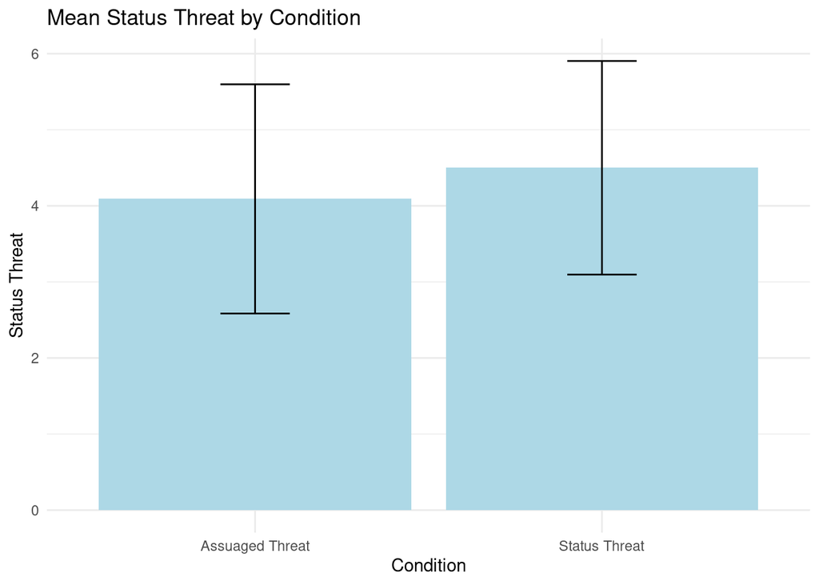

```r
#calculate mean of perceived threat
cleaned_data %>%
  group_by(Condition) %>%
  summarize(
    mean_statusthreat = mean(statusThreatPercept),
    sd_statusthreat = sd(statusThreatPercept)
  ) -> summarised_data

# Create bar chart with error bars
ggplot(summarised_data, aes(x = Condition, y = mean_statusthreat)) +
  geom_bar(stat = "identity", fill = "lightblue") +
  geom_errorbar(aes(ymin = mean_statusthreat - sd_statusthreat,
                    ymax = mean_statusthreat + sd_statusthreat),
                width = 0.2,
                position = position_dodge(0.9),
                color = "black") +
  labs(title = "Mean Status Threat by Condition",
       x = "Condition",
       y = "Status Threat") +
  theme_minimal()
```

### Confirmatory analysis

In analysis, I plan to use a linear model for confirmatory analyses, as I have two conditions and need to control for various covariates (demographics and baseline ideologies). The original paper and replication utilized ANCOVAs for analyses: “Unless otherwise noted, reported analyses for Studies 3a and 3b are ANCOVAs with experimental condition as the independent variable and demographic characteristics and baseline political ideology as co-variates.” I used a linear model to examine the reported role of group status threat (the condition assignment) on policy preferences for White Americans, incorporating participants’ baseline political ideologies into the model.

```r
model <- lm(ConsPolicyScore ~ Condition + Age + BaselinePolIdeo + Gender1 + Education, data = cleaned_data)
summary(model)
```

```
Call:
lm(formula = ConsPolicyScore ~ Condition + Age + BaselinePolIdeo +
    Gender1 + Education, data = cleaned_data)

Residuals:
    Min      1Q  Median      3Q     Max
-5.5813 -1.4774 -0.3103  1.4863  6.7293

Coefficients:
                       Estimate Std. Error t value Pr(>|t|)
(Intercept)            -5.77493    1.28275  -4.502 1.56e-05 ***
ConditionStatus Threat  0.32612    0.42473   0.768   0.4441
Age                     0.06386    0.01368   4.668 7.94e-06 ***
BaselinePolIdeo         1.54296    0.11753  13.128  < 2e-16 ***
Gender1                -0.95583    0.45158  -2.117   0.0363 *
Education               0.05384    0.15254   0.353   0.7247
---
Signif. codes:  0 '***' 0.001 '**' 0.01 '*' 0.05 '.' 0.1 ' ' 1

Residual standard error: 2.3 on 121 degrees of freedom
Multiple R-squared:  0.6465,    Adjusted R-squared:  0.6319
F-statistic: 44.26 on 5 and 121 DF,  p-value: < 2.2e-16
```

```r
#mean scores and SDs for overall policy attitude outcomes
cleaned_data |>
  group_by(Condition) |>
  summarize(
    Mean = mean(ConsPolicyScore),
    SD = sd(ConsPolicyScore)
  )
```

```
# A tibble: 2 × 3
  Condition         Mean    SD
  <chr>            <dbl> <dbl>
1 Assuaged Threat  0.391  4.07
2 Status Threat   -0.299  3.57
```

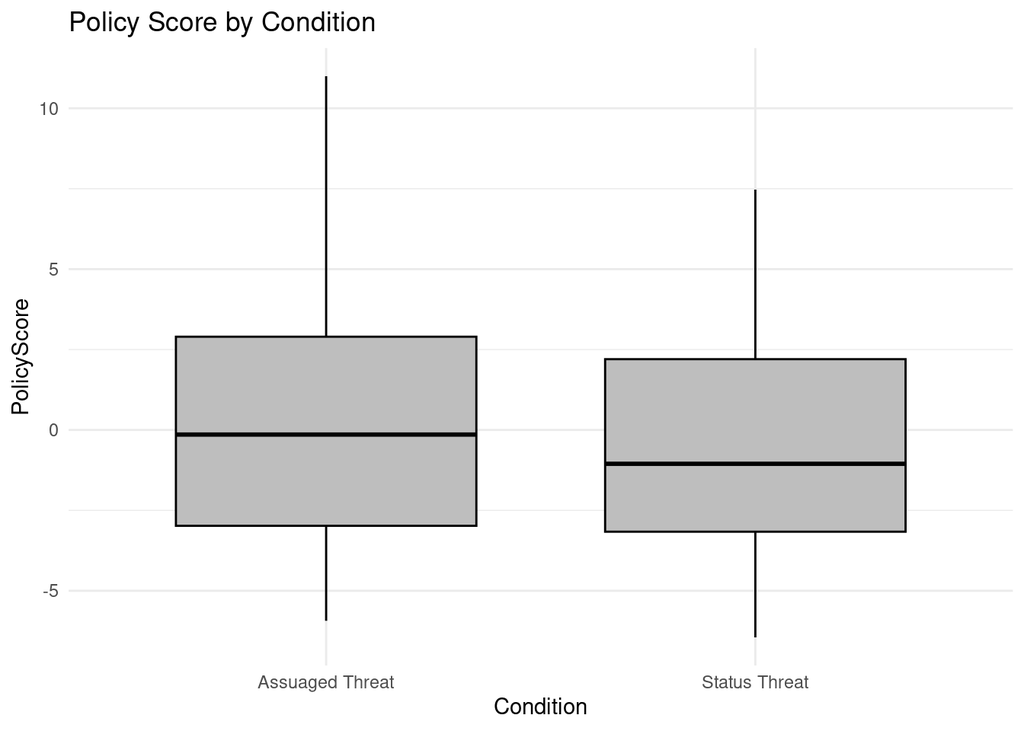

```r
# box plot of policy preferences; more positive scores = more support for conservative policy
ggplot(cleaned_data, aes(x = Condition, y = ConsPolicyScore)) +
  geom_boxplot(fill = "gray", color = "black", width = 0.7) +
  labs(title = "Policy Score by Condition",
       x = "Condition",
       y = "PolicyScore") +
  theme_minimal()
```

### Exploratory analyses

#### Exploratory Analysis #1: How do policy preferences differ as a function of baseline ideology?

```r
model <- lm(ConsPolicyScore ~ BaselinePolIdeo, data = cleaned_data)
summary(model)
```

```
Call:
lm(formula = ConsPolicyScore ~ BaselinePolIdeo, data = cleaned_data)

Residuals:
    Min      1Q  Median      3Q     Max
-5.1868 -1.9652 -0.0685  1.8256  8.0443

Coefficients:
                Estimate Std. Error t value Pr(>|t|)
(Intercept)      -4.4518     0.4093  -10.88   <2e-16 ***
BaselinePolIdeo   1.5949     0.1234   12.92   <2e-16 ***
---
Signif. codes:  0 '***' 0.001 '**' 0.01 '*' 0.05 '.' 0.1 ' ' 1

Residual standard error: 2.491 on 125 degrees of freedom
Multiple R-squared:  0.5719,    Adjusted R-squared:  0.5684
F-statistic:   167 on 1 and 125 DF,  p-value: < 2.2e-16
```

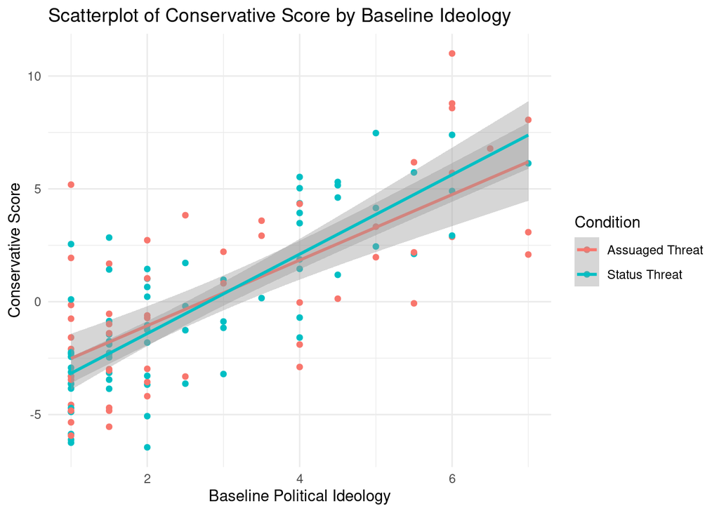

```r
# box plot of policy preferences; more positive scores = more support for conservative policy
ggplot(cleaned_data, aes(x = BaselinePolIdeo, y = ConsPolicyScore, color = Condition)) +
  geom_point() +
  geom_smooth(method = "lm", se = TRUE) +
  labs(title = "Scatterplot of Conservative Score by Baseline Ideology",
       x = "Baseline Political Ideology",
       y = "Conservative Score") +
  theme_minimal()
```

#### Exploratory Analysis #2: How might the results differ without any covariates included in the model?

```r
model <- lm(ConsPolicyScore ~ Condition, data = cleaned_data) #running linear model with no covariates
summary(model)
```

```
Call:
lm(formula = ConsPolicyScore ~ Condition, data = cleaned_data)

Residuals:
    Min      1Q  Median      3Q     Max
-6.3231 -2.9932 -0.7447  2.5077 10.6062

Coefficients:
                       Estimate Std. Error t value Pr(>|t|)
(Intercept)              0.3908     0.5112   0.765    0.446
ConditionStatus Threat  -0.6894     0.6789  -1.015    0.312

Residual standard error: 3.791 on 125 degrees of freedom
Multiple R-squared:  0.008181,  Adjusted R-squared:  0.0002468
F-statistic: 1.031 on 1 and 125 DF,  p-value: 0.3119
```

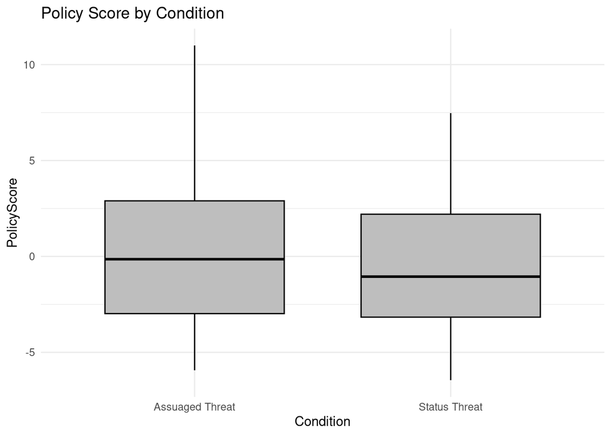

```r
# box plot of policy preferences; more positive scores = more support for conservative policy
ggplot(cleaned_data, aes(x = Condition, y = ConsPolicyScore)) +
  geom_boxplot(fill = "gray", color = "black", width = 0.7) +
  labs(title = "Policy Score by Condition",
       x = "Condition",
       y = "PolicyScore") +
  theme_minimal()
```

The effect is still not significant, although moves closer to significance.

#### Exploratory Analysis #4: What would’ve happened if I filtered the data differently? Perhaps the comprehension check questions were confusing – they did not ask participants to make a judgement solely based on the article. In this first analysis, I re-run the mean status threat scores as well as the linear model without filtering out participants by their responses on the final two comprehension checks. After the edits in the filtering code, the subsequent scripts are identical and are thus hidden here for readibility.

```r
data_filter = RawData |>
  filter(
    Consent == 1, # Gave consent
    Citizen == 1, # US Citizen
    Residency_1 == 1, #only select US residents
    Race1 == 3, #only select White participants
    primeRepeat == 2) #Filter out any participants who have read the stimuli before
cleaned_data = data_filter |>
  select(c(Consent:GenPartyAffiliation, groupGrowth:primeRepeat, Condition)) # select columns for analysis
cleaned_data = data_filter |>
  select(c(Consent:GenPartyAffiliation, groupGrowth:primeRepeat, Condition)) # select columns for analysis
```

```r
# Perform a t-test + print result
result <- t.test(statusThreatPercept ~ Condition, data = cleaned_data)
print(result)
```

```
    Welch Two Sample t-test

data:  statusThreatPercept by Condition
t = -0.85371, df = 166.6, p-value = 0.3945
alternative hypothesis: true difference in means between group Assuaged Threat and group Status Threat is not equal to 0
95 percent confidence interval:
 -0.6186205  0.2451265
sample estimates:
mean in group Assuaged Threat   mean in group Status Threat
                     4.313253                      4.500000
```

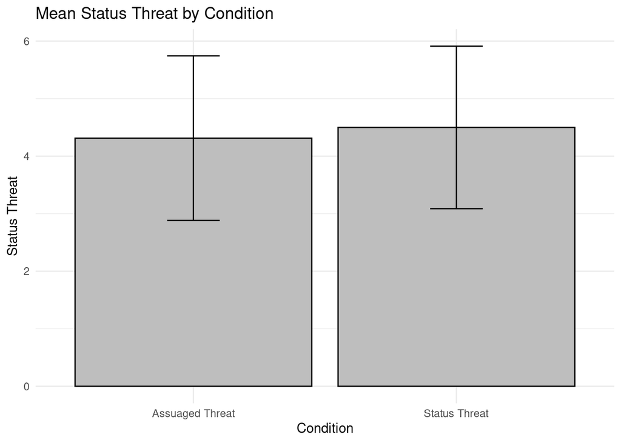

```r
#calculate mean of perceived threat
cleaned_data %>%
  group_by(Condition) %>%
  summarize(
    mean_statusthreat = mean(statusThreatPercept),
    sd_statusthreat = sd(statusThreatPercept)
  ) -> summarised_data

# Create bar chart with error bars
ggplot(summarised_data, aes(x = Condition, y = mean_statusthreat)) +
  geom_bar(stat = "identity", fill = "gray", color = "black") +
  geom_errorbar(aes(ymin = mean_statusthreat - sd_statusthreat,
                    ymax = mean_statusthreat + sd_statusthreat),
                width = 0.2,
                position = position_dodge(0.9),
                color = "black") +
  labs(title = "Mean Status Threat by Condition",
       x = "Condition",
       y = "Status Threat") +
  theme_minimal()
```

```r
exp_model <- lm(ConsPolicyScore ~ Condition + Age + BaselinePolIdeo + Gender1 + Education, data = cleaned_data) #running linear model
summary(exp_model)
```

```
Call:
lm(formula = ConsPolicyScore ~ Condition + Age + BaselinePolIdeo +
    Gender1 + Education, data = cleaned_data)

Residuals:
    Min      1Q  Median      3Q     Max
-7.0062 -1.5663 -0.0781  1.5717  6.7682

Coefficients:
                       Estimate Std. Error t value Pr(>|t|)
(Intercept)            -5.92071    1.13283  -5.226 5.23e-07 ***
ConditionStatus Threat  0.08330    0.36669   0.227    0.821
Age                     0.05144    0.01237   4.157 5.19e-05 ***
BaselinePolIdeo         1.52284    0.10525  14.470  < 2e-16 ***
Gender1                -0.53406    0.39351  -1.357    0.177
Education               0.06225    0.13650   0.456    0.649
---
Signif. codes:  0 '***' 0.001 '**' 0.01 '*' 0.05 '.' 0.1 ' ' 1

Residual standard error: 2.338 on 163 degrees of freedom
Multiple R-squared:  0.6135,    Adjusted R-squared:  0.6017
F-statistic: 51.75 on 5 and 163 DF,  p-value: < 2.2e-16
```

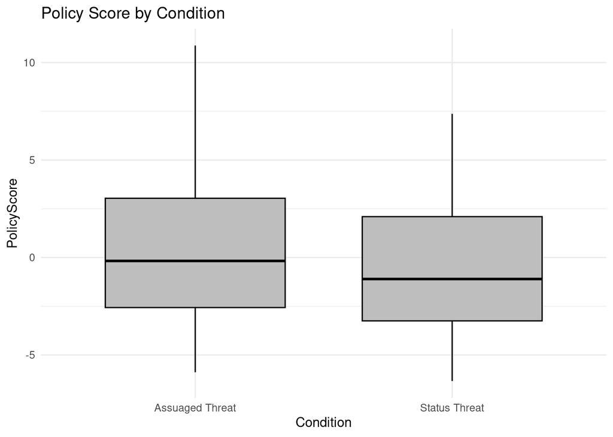

```r
# box plot of policy preferences; more positive scores = more support for conservative policy
ggplot(cleaned_data, aes(x = Condition, y = ConsPolicyScore)) +
  geom_boxplot(fill = "gray", color = "black", width = 0.7) +
  labs(title = "Policy Score by Condition",
       x = "Condition",
       y = "PolicyScore") +
  theme_minimal()
```

The results are still not significant, and actually seem to move closer to the same mean scores.

## Discussion

Side by side graphs:

Original study does not have a graph.

Key result on the difference between the “assuaged threat” and “status threat” : “participants in the status-threat condition reported more support for conservative policy positions than did participants in the assuaged-threat condition, F(1, 161) = 7.63, p = .006” marginal means: assuaged: -.08 (se:.06), status threat .15 (se: .06)

Replication:

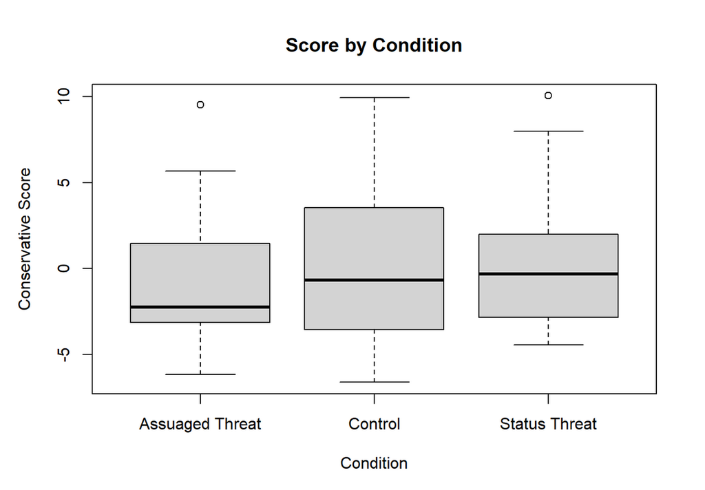

```r
knitr::include_graphics("replication_graph.png")
```

Assuaged Threat: mean -.721 (sd 3.82); Status threat: mean .271 (sd 3.51)

Rescue:

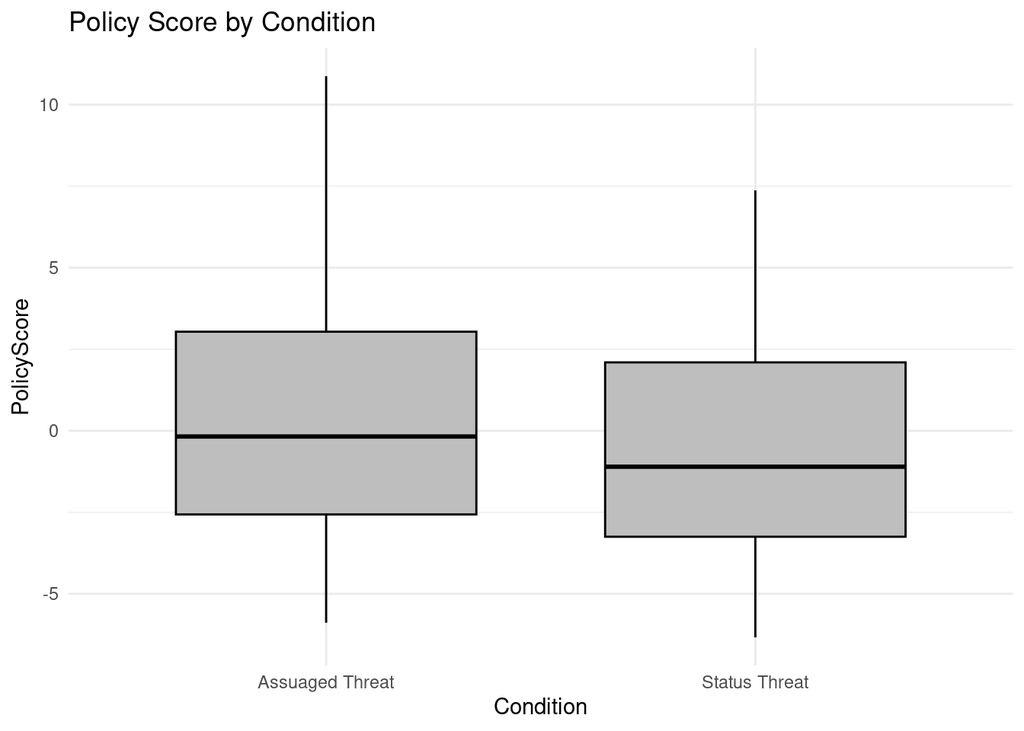

```r
# box plot of policy preferences; more positive scores = more support for conservative policy
ggplot(cleaned_data, aes(x = Condition, y = ConsPolicyScore)) +
  geom_boxplot(fill = "gray", color = "black", width = 0.7) +
  labs(title = "Policy Score by Condition",
       x = "Condition",
       y = "PolicyScore") +
  theme_minimal()
```

```r
cleaned_data |>
  group_by(Condition) |>
  summarize(
    Mean = mean(ConsPolicyScore),
    SD = sd(ConsPolicyScore)
  )
```

```
# A tibble: 2 × 3
  Condition         Mean    SD
  <chr>            <dbl> <dbl>
1 Assuaged Threat  0.446  3.85
2 Status Threat   -0.431  3.53
```

## Mini meta analysis

```r
# Function to calculate Cohen's f from eta-squared values from original paper and from the first replication
cohen_f_from_eta_squared <- function(eta_squared) {
  return(sqrt(eta_squared / (1 - eta_squared)))
}

# Eta-squared values from your ANOVA analyses
eta_squared_original <- .05
eta_squared_rep <- 0.0025564712

# Calculate Cohen's f for each eta-squared value
cohen_f_1 <- cohen_f_from_eta_squared(eta_squared_original)
cohen_f_2 <- cohen_f_from_eta_squared(eta_squared_rep)

# Extract R-squared and degrees of freedom from the rescue regression model
R_squared <- summary(model)$r.squared
df_regression <- length(coefficients(model)) - 1
df_residuals <- df.residual(model)

# Calculate Cohen's f for rescue
cohen_f <- sqrt(R_squared / (1 - R_squared) * (df_regression / df_residuals))

# Print the result
cat("Cohen's f for Original Study:", cohen_f_1, "\n")
```

```
Cohen's f for Original Study: 0.2294157
```

```r
cat("Cohen's f for Replication 1:", cohen_f_2, "\n")
```

```
Cohen's f for Replication 1: 0.05062631
```

```r
cat("Cohen's f for the Rescue:", cohen_f, "\n")
```

```
Cohen's f for the Rescue: 0.008123487
```

### Commentary

One key driver of the failure to replicate may have been the smaller-than-expected sample size. It’s unclear why so many participants failed the comprehension check in this trial, while very few failed the same check in the original and in the first replication. Given the increasingly polarized political climate, future research may need to ensure that such an article manipulation is a sufficient prime if there is already increased baseline levels of status threat for White Americans.

Exploratory analysis provide some early insight into why this replication may have failed. While excluded participants may have played a role in the reduced sample size, the main issue seemed to be the efficacy of the article stimuli in sufficiently manipulating perceptions of status threat.